# **Lab 5: The area-based approach**

Hans Ole Ørka, 08. October 2026

**Goal:** Learn to extract point metrics and carry out an forest inventory project using the area-based approach.

**Data download:**

- https://eduumb.sharepoint.com/:u:/s/team_mina305instructors/IQDN2DTrCma0SpFjY8ApwC9-AW_vx6rz4JkFJ1dHC78WsQA?e=5P0OQs

The lab exercise is carried out using [R](https://www.r-project.org/) and the [lidR-package](https://github.com/r-lidar/lidR). The [lidRBook](https://r-lidar.github.io/lidRbook/) is a fantastic resource!

# **Intro area-based approach**

The basic steps of the area-based method are as follows (Næsset 2014):

1. Stand delineation and interpretation: The forest stands in the area of interest (AOI) are delineated. Delineation using orthophotos or stereo photogrammery is commonly adopted. Manual interpretation is conducted to derive properties like for example tree species, site quality, and age which are required either as primary variables that are sought for every stand in the inventory or used for stratification of the inventory.
2. Sample survey: A field sample survey is conducted across the entire AOI. Such surveys are commonly performed according to stratified sampling schemes applying systematic sampling with a random start or systematic cluster sampling. Thus, the collected sample of field plots can be considered as a (stratified) probability sample. Conventional field data are collected on the plots (e.g. tree diameter and height) and the plots are accurately geo-referenced.
3. ALS acquisition and processing: ALS data are acquired for the AOI. The entire AOI is partitioned into regular grid cells with cell size equal to the sample plot size. Various metrics are derived from the 3D ALS point cloud for each cell and field plot. These metrics basically belong to two distinct “families” of variables, namely (1) canopy height-related variables like order statistics, mean height, and variability among the heights of the ALS echoes and (2) canopy density metrics which characterize the frequency of echoes above a certain height threshold relative to the total number of recorded echoes. A wide range of other metrics or slightly modified metrics can be found in the literature.
4. Model fitting: Based on the sample plots regression models with biophysical properties such as mean height, basal area and volume as dependent variables are fitted with ALS metrics used as independent variables.
5. Stand-wise estimation: Finally, the fitted models are used to predict the biophysical properties of interest for every grid cell. The individual cell estimates are aggregated to stand estimates.

This lab will focus on steps 3 and 4.

# **Part 1: Compute point cloud metrics**

## Read and normalize point cloud data

The following code reads a rectangle of the 2021 LAZ file from Frydenhaug and extract a “field plot” located on UTM32 East 600080 North 6615950 of 400 m².

```r
library(lidR)
lasFile <- "data/frydenhaug/als2021.laz" # Filename
filter <- "-keep_xy 599850 6615750 600250 6616030 -keep_class 1 2" # ALS returns inside a boundary, only class 1 (unclassified), and 2 (ground)
lasdata <- readLAS(lasFile,filter=filter)
```

```r
lasdz <- normalize_height(lasdata, tin())
las <- clip_circle(lasdz, 600080, 6615950, radius = sqrt(400/pi))
plot(las)
```

The las-file attributes can be access as in a standard data.frame.

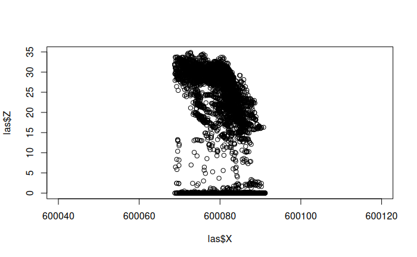

```r
plot(las$X,las$Z,asp=1) #asp = setting the X Y axes equal
```

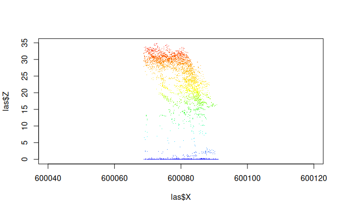

```r
#Make pretty plot
source("R/laser.colors.R") # Reads in a predefined function
plot(las$X,las$Z,asp=1,pch=".",col=laser.colors(las$Z)) #asp = setting the X Y axes equal
```

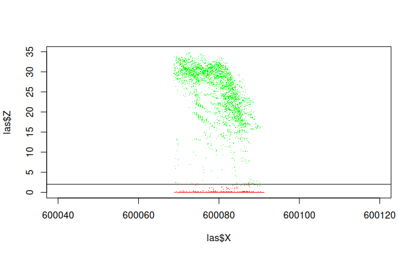

```r
# Threshold of 2 m "The Nilsson rule" :-)
plot(las$X,las$Z,col=ifelse(las$Z>=2,"green","red"),asp=1,pch=".")
abline(h=2)
```

## Height metrics

Compute mean height with a threshold >= 2 m

```r
Hmean <- mean(las$Z[las$Z>=2])
Hmean # To print could also have used () before and after expression above
```

```
[1] 25.08254
```

> *TASK:* Compute standard deviation of height (function *sd*), height percentiles (function *quantile*) and coefficient of variation cv = sd/mean

```r
(Hsd <- sd(las$Z[las$Z>=2]))
```

```
[1] 6.105216
```

```r
(Hcv <- Hsd/Hmean)
```

```
[1] 0.243405
```

```r
seq(0,1,0.05) # To create a sequence of numbers ?seq for info
```

```
 [1] 0.00 0.05 0.10 0.15 0.20 0.25 0.30 0.35 0.40 0.45 0.50 0.55 0.60 0.65 0.70 0.75 0.80 0.85 0.90 0.95 1.00
```

```r
q <- quantile(las$Z[las$Z>=2],probs=seq(0,1,0.05))
names(q) <- paste("H",seq(0,1,0.05)*100,sep="")
paste0("H",seq(0,1,0.05)*100)
```

```
 [1] "H0"   "H5"   "H10"  "H15"  "H20"  "H25"  "H30"  "H35"  "H40"  "H45"  "H50"  "H55"  "H60"  "H65"  "H70"  "H75"  "H80"  "H85"  "H90"  "H95"  "H100"
```

## Density metrics

Compute density metrics D0 and D9 with a threshold >= 2 m.

```r
ntot <- length(las$Z) # or nrow(las)
nabove <- length(las$Z[las$Z>=2])
(D0 = nabove/ntot)
```

```
[1] 0.6956864
```

```r
ntot <- length(las$Z)# nrow(las)
H95 <- quantile(las$Z[las$Z>=2],probs=0.95)
layer <- (((H95 - 2)/10 )*9)+2
nabove <- length(las$Z[las$Z>=layer])
(D9 = nabove/ntot)
```

```
[1] 0.2381328
```

Implement for all density metrics

```r
layers <-  c(0:9)*(quantile(las$Z[las$Z >= 2], probs=0.95) - 2)/10 + 2
density.metrics <- c()
for(i in c(1:10)){
  ntot <- length(las$Z)# nrow(las)
  nabove <- length(las$Z[las$Z>=layers[i]])
  density.metrics[i] <- nabove/ntot
}
density.metrics
```

```
 [1] 0.6956864 0.6882017 0.6844593 0.6779594 0.6623991 0.6263541 0.5459917 0.4587355 0.3697065 0.2381328
```

## Compute metrics for different echo categories

> *TASK:* The standard approach in the area-based methods is to separate metrics based on first and last echoes. Compute the metrics above for the two different types of echos (returns). Hint use variables ReturnNumber and NumberOfReturns. First returns (first of many + single) ReturnNumber == 1 and Last returns (last of many) ReturnNumber == NumberOfReturns & ReturnNumber != 1

```r
# Filter first of many and single - 3 different ways to obtain the same result
names(las) # List the different attributes
```

```
 [1] "X"                 "Y"                 "Z"                 "gpstime"           "Intensity"         "ReturnNumber"      "NumberOfReturns"   "ScanDirectionFlag" "EdgeOfFlightline"
[10] "Classification"    "Synthetic_flag"    "Keypoint_flag"     "Withheld_flag"     "ScanAngleRank"     "UserData"          "PointSourceID"     "Zref"
```

```r
first <- filter_first(las)
dim(first)
```

```
[1] 2966   17
```

```r
first <- filter_poi(las, ReturnNumber == 1)
dim(first)
```

```
[1] 2966   17
```

```r
first <- las[las$ReturnNumber == 1]
dim(first)
```

```
[1] 2966   17
```

```r
#Filter last
last <- filter_last(las) #Last of many and single!!!!!
dim(last)
```

```
[1] 2819   17
```

```r
last <- filter_poi(las, ReturnNumber == NumberOfReturns & ReturnNumber != 1) # Only Last of many
dim(last)
```

```
[1] 1441   17
```

> *TASK:* Do the same for the image matching point cloud dap2021.las

## Compute all metrics using a predefined function

In lidR there exists functions to calculate point cloud metrics e.g. *stdmetrics_z*. Explanation of metrics computed using the *stdmetrics_z* function can be found [here](https://github.com/r-lidar/lidR/wiki/stdmetrics). I have provided a function for the point cloud metrics discussed that follow the Norwegian tradition and the implementation of (Næsset and Gobakken 2008) .

```r
source("R/stdmetricsNOR.R") # Function computing point cloud metrics the after the Norwegian tradition [@Naesset2008-cd]
dat <- cloud_metrics(las,func=~stdmetricsNOR(Z))
data.frame(dat)
```

| Hmax | Hmean | Hsd | Hcv | Hkurt | Hskewness | H10 | H20 | H30 | H40 | H50 | H60 | H70 | H80 | H90 | H95 | D0 | D1 | D2 | D3 | D4 | D5 | D6 | D7 | D8 | D9 |
| --- | --- | --- | --- | --- | --- | --- | --- | --- | --- | --- | --- | --- | --- | --- | --- | --- | --- | --- | --- | --- | --- | --- | --- | --- | --- |
| 34.86 | 25.08254 | 6.105216 | 0.243405 | 0.9929673 | -1.021428 | 17.08 | 19.8 | 22.06 | 24.16 | 26.865 | 28.51 | 29.5 | 30.42 | 31.34 | 32.16 | 0.6956864 | 0.6882017 | 0.6844593 | 0.6779594 | 0.6623991 | 0.6263541 | 0.5459917 | 0.4587355 | 0.3697065 | 0.2381328 |

# **Part 2: Area-based approach**

## Read and inspect laser data

```r
library(lidR)
lasFile <- "data/vaaler/las/0008.las"
filter <- "-keep_xy 606200 6600150 606500 6600450"
las <- readLAS(lasFile,filter=filter)
```

```r
table(las$Classification)
```

```
     0      1      2      7
228493 107111  93453   1898
```

## Normalizing ALS data

```r
lasdz <- normalize_height(las, tin())
table(lasdz$Classification)
```

```
     0      1      2      7
228493 107111  93453   1898
```

```r
lasdz_no_noise <- classify_noise(lasdz,algorithm=ivf(5,2)) # classify returns associated to noise in class 18
table(lasdz_no_noise$Classification)
```

```
     0      1      2      7     18
228490 107111  93453   1894      7
```

```r
lasdz_filtered <- filter_poi(lasdz_no_noise,Classification != 7 & Classification != 18) # 7 and 18: noise
plot(lasdz_filtered,color="Classification")
plot(lasdz_filtered)
```

## Compute metrics

```r
grd <- pixel_metrics(lasdz_filtered,func = ~stdmetricsNOR(Z),res=sqrt(250),filter= ~ReturnNumber == 1)
head(grd)
```

|  | Hmax | Hmean | Hsd | Hcv | Hkurt | Hskewness | H10 | H20 | H30 | H40 | H50 | H60 | H70 | H80 | H90 | H95 | D0 | D1 | D2 | D3 | D4 | D5 | D6 | D7 | D8 | D9 |
| --- | --- | --- | --- | --- | --- | --- | --- | --- | --- | --- | --- | --- | --- | --- | --- | --- | --- | --- | --- | --- | --- | --- | --- | --- | --- | --- |
| 1 | -Inf | NA | NA | NA | NA | NA | NA | NA | NA | NA | NA | NA | NA | NA | NA | NA | 0.0000000 | 0.0000000 | 0.0000000 | 0.0000000 | 0.0000000 | 0.0000000 | 0.0000000 | 0.0000000 | 0.0000000 | 0.0000000 |
| 2 | 8.44 | 7.58250 | 1.2626361 | 0.16651977 | 1.3661882 | -1.7119572 | 6.662 | 7.692 | 7.866 | 7.908 | 7.990 | 8.066 | 8.087 | 8.150 | 8.265 | 8.3525 | 0.1379310 | 0.1379310 | 0.1379310 | 0.1379310 | 0.1206897 | 0.1206897 | 0.1206897 | 0.1206897 | 0.1206897 | 0.1034483 |
| 3 | 19.48 | 17.06591 | 1.2618341 | 0.07393887 | -0.8362558 | 0.3749147 | 15.634 | 16.096 | 16.280 | 16.662 | 16.830 | 17.352 | 17.744 | 17.926 | 19.086 | 19.3525 | 0.3283582 | 0.3283582 | 0.3283582 | 0.3283582 | 0.3283582 | 0.3283582 | 0.3283582 | 0.3283582 | 0.2686567 | 0.1194030 |
| 4 | 2.54 | 2.38500 | 0.1328822 | 0.05571583 | -0.6791394 | -0.7273167 | 2.212 | 2.316 | 2.320 | 2.346 | 2.425 | 2.448 | 2.491 | 2.500 | 2.507 | 2.5205 | 0.2413793 | 0.2413793 | 0.2241379 | 0.2241379 | 0.2068966 | 0.2068966 | 0.1551724 | 0.1379310 | 0.1206897 | 0.0862069 |
| 5 | 2.35 | 2.19500 | 0.1204159 | 0.05485920 | -2.1052883 | 0.2856478 | 2.096 | 2.102 | 2.108 | 2.134 | 2.170 | 2.206 | 2.242 | 2.278 | 2.314 | 2.3320 | 0.1000000 | 0.1000000 | 0.1000000 | 0.0750000 | 0.0500000 | 0.0500000 | 0.0500000 | 0.0250000 | 0.0250000 | 0.0250000 |
| 6 | -Inf | NA | NA | NA | NA | NA | NA | NA | NA | NA | NA | NA | NA | NA | NA | NA | 0.0000000 | 0.0000000 | 0.0000000 | 0.0000000 | 0.0000000 | 0.0000000 | 0.0000000 | 0.0000000 | 0.0000000 | 0.0000000 |

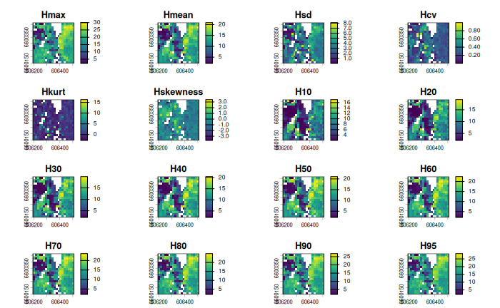

```r
plot(grd)
```

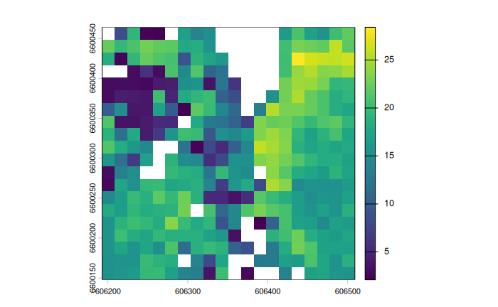

```r
plot(grd$H95)
```

## Processing multiple files

Point clouds are commonly distributed in the form of multiple files that cover specific areas. Each of these files corresponds to a square-shaped region, often referred to as a “tile,” and typically has a size of around 200MB. The lidR package provides a comprehensive set of tools for efficiently managing and processing such data. It employs a tile processing system known as a “catalog” to help users navigate and gain an overview of the individual files.

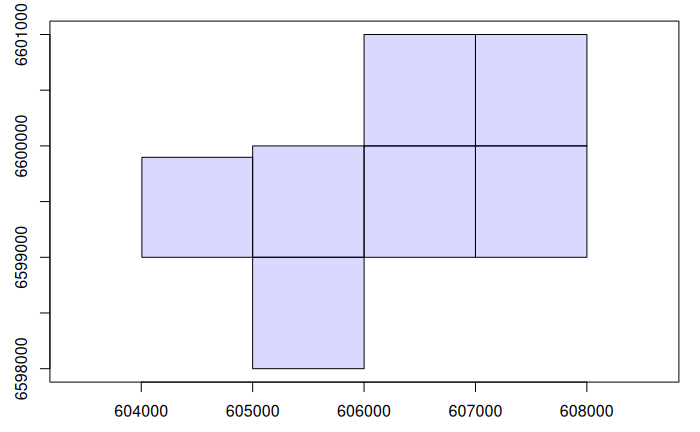

```r
ctg <- readLAScatalog("data/vaaler/las/")
plot(ctg)
```

```r
ctg
```

```
class       : LAScatalog (v1.4 format 6)
extent      : 604005.6, 608000.5, 6598000, 6601000 (xmin, xmax, ymin, ymax)
coord. ref. : WGS 84 / UTM zone 32N
area        : 6.9 km²
points      : 41.57 million points
type        : airborne
density     : 6 points/m²
density     : 4.1 pulses/m²
num. files  : 7
```

## Normalize ALS data from multiple files

This take some time, maybe use the skip this step and use data from “data/vaaler/lasdz/”

```r
ctg <- readLAScatalog("data/vaaler/las/")
opt_filter(ctg) <- "-keep_classification 0 1 2"
opt_output_files(ctg) <-  paste0("data/vaaler/dz/", "/{ORIGINALFILENAME}_norm")
# Not run ctgdz <- normalize_height(ctg, tin())
```

## Extract metrics for reference data

```r
library(sf)
library(lidR)
ctgdz <- readLAScatalog("data/vaaler/lasdz/")
plot(ctgdz)
st_layers("data/vaaler/sample_plots.gpkg") # list different layers in gpkg
```

```
Driver: GPKG
Available layers:
```

| layer_name | geometry_type | features | fields | crs_name |
| --- | --- | --- | --- | --- |
| field_plots | Point | 47 | 3 | WGS 84 / UTM zone 32N |

```r
sample_plots <- read_sf("data/vaaler/sample_plots.gpkg","field_plots")
head(sample_plots)
```

```
Simple feature collection with 6 features and 3 fields
Geometry type: POINT
Dimension:     XY
Bounding box:  xmin: 605370.6 ymin: 6598604 xmax: 607622.3 ymax: 6600178
Projected CRS: WGS 84 / UTM zone 32N
```

| ID | V | TH | geom |
| --- | --- | --- | --- |
| P1 | 171.48019 | 17.04191 |  |
| P2 | 161.93926 | 19.97162 |  |
| P3 | 225.83901 | 20.90268 |  |
| P4 | 212.65039 | 20.44330 |  |
| P5 | 16.12858 | 12.03871 |  |
| P6 | 158.50063 | 16.71721 |  |

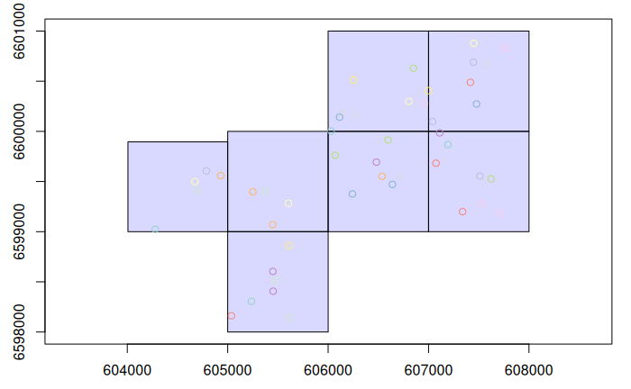

```r
plot(sample_plots,add=T)
```

```r
#Function to process the las-catalog using the stdmetricsNOR function for each sample plot of 250 m^2
sqrt(250/pi) # Compute radius of plot
```

```
[1] 8.920621
```

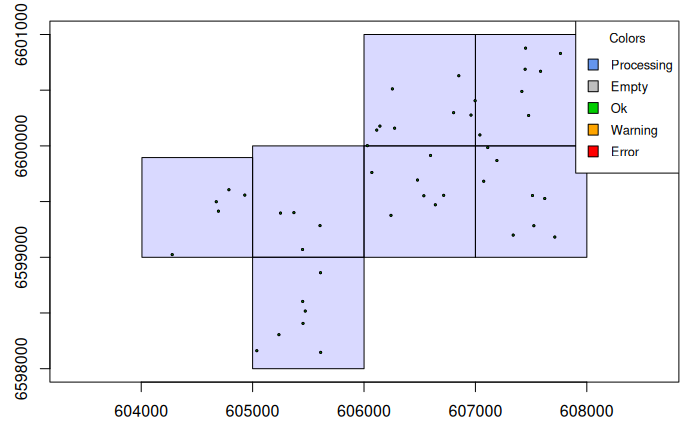

```r
options(lidR.progress = FALSE)
plots <- plot_metrics(ctgdz, ~stdmetricsNOR(Z), sample_plots, radius = 8.92)
```

```r
head(plots)
```

```
Simple feature collection with 6 features and 29 fields
Geometry type: POINT
Dimension:     XY
Bounding box:  xmin: 605370.6 ymin: 6598604 xmax: 607622.3 ymax: 6600178
Projected CRS: WGS 84 / UTM zone 32N
  ID         V       TH  Hmax     Hmean      Hsd       Hcv      Hkurt  Hskewness   H10    H20    H30    H40   H50    H60    H70    H80    H90     H95        D0        D1        D2
1 P1 171.48019 17.04191 22.34 11.575928 3.873993 0.3346594 -0.1748064 -0.3350647 6.120  8.004  9.781 11.288 12.21 12.952 13.860 14.646 15.873 17.2300 0.6223840 0.6023658 0.5809827
2 P2 161.93926 19.97162 22.02 13.729396 5.001242 0.3642725 -0.1523649 -0.9480473 4.554  9.414 12.608 14.118 15.37 16.406 16.994 17.602 18.808 19.2180 0.4995563 0.4631766 0.4427684
3 P3 225.83901 20.90268 23.03 12.354471 5.200843 0.4209685 -1.0874744 -0.1413153 5.074  7.178  8.572 10.538 13.24 14.620 15.890 17.214 18.790 20.1490 0.6852527 0.6524231 0.5961438
4 P4 212.65039 20.44330 21.13 13.532236 4.209595 0.3110791 -0.2508123 -0.6051007 7.312 10.102 11.592 13.040 14.10 15.342 16.084 17.190 18.580 19.4240 0.6914324 0.6773762 0.6539491
5 P5  16.12858 12.03871 19.97  7.284962 4.085395 0.5607983  1.3721603  1.3291047 3.145  3.920  4.790  5.600  6.38  7.260  8.260  9.520 13.300 17.3475 0.6905996 0.5862324 0.4581791
6 P6 158.50063 16.71721 19.36 10.564682 3.958364 0.3746789 -0.7466849 -0.3892359 4.480  6.544  8.481 10.040 11.44 12.340 13.260 14.186 14.863 15.6665 0.6494668 0.6164431 0.5761954
         D3        D4        D5         D6         D7         D8         D9                     geom
1 0.5454959 0.4940855 0.4399454 0.37989081 0.26706096 0.15605096 0.06960874 POINT (607192.8 6599869)
2 0.4250222 0.4046140 0.3833185 0.35847382 0.30346051 0.23158829 0.10559006 POINT (605370.6 6599401)
3 0.5325690 0.4544033 0.3981240 0.35435122 0.26836894 0.17717561 0.08650339 POINT (605449.5 6598604)
4 0.6244980 0.5856760 0.5361446 0.45113788 0.34002677 0.22556894 0.11244980 POINT (606142.7 6600178)
5 0.3260548 0.2168764 0.1321244 0.08697261 0.07253886 0.06328645 0.05551443 POINT (607622.3 6599528)
6 0.5331957 0.4895081 0.4389405 0.38390093 0.31922945 0.21878225 0.11936705 POINT (607524.6 6599283)
```

```r
# #Example of 2 plots
# P1 <- lidR::clip_roi(ctgdz, sample_plots[sample_plots$ID=="P1",], radius = 8.92)
# P5 <- lidR::clip_roi(ctgdz, sample_plots[sample_plots$ID=="P5",], radius = 8.92)
# plot(P1)
# plot(P5)
```

## Create regression models

Below we create the regression model for top height (TH)

```r
modTH <- lm(TH~H95,data=plots)
summary(modTH)
```

```
Call:
lm(formula = TH ~ H95, data = plots)

Residuals:
    Min      1Q  Median      3Q     Max
-5.7837 -0.4795  0.3837  0.7657  2.4892

Coefficients:
            Estimate Std. Error t value Pr(>|t|)
(Intercept) -1.11077    1.10449  -1.006     0.32
H95          1.09141    0.06269  17.409   <2e-16 ***
---
Signif. codes:  0 ‘***’ 0.001 ‘**’ 0.01 ‘*’ 0.05 ‘.’ 0.1 ‘ ’ 1

Residual standard error: 1.523 on 45 degrees of freedom
Multiple R-squared:  0.8707,    Adjusted R-squared:  0.8678
F-statistic: 303.1 on 1 and 45 DF,  p-value: < 2.2e-16
```

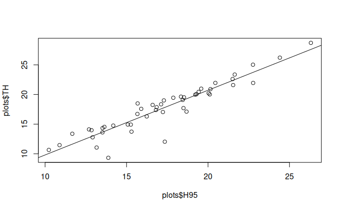

```r
plot(plots$H95,plots$TH)
abline(coef(modTH))
```

Modelling volume (V) is often done using on variable describing height and one describing the density.

```r
modV <- lm(V~Hmean+D5,data=plots)
summary(modV)
```

```
Call:
lm(formula = V ~ Hmean + D5, data = plots)

Residuals:
    Min      1Q  Median      3Q     Max
-101.38  -44.24  -15.34   30.42  258.36

Coefficients:
            Estimate Std. Error t value Pr(>|t|)
(Intercept) -173.494     34.739  -4.994 9.83e-06 ***
Hmean         18.584      4.369   4.254 0.000108 ***
D5           330.010     91.058   3.624 0.000748 ***
---
Signif. codes:  0 ‘***’ 0.001 ‘**’ 0.01 ‘*’ 0.05 ‘.’ 0.1 ‘ ’ 1

Residual standard error: 64.8 on 44 degrees of freedom
Multiple R-squared:  0.7352,    Adjusted R-squared:  0.7231
F-statistic: 61.08 on 2 and 44 DF,  p-value: 2.018e-13
```

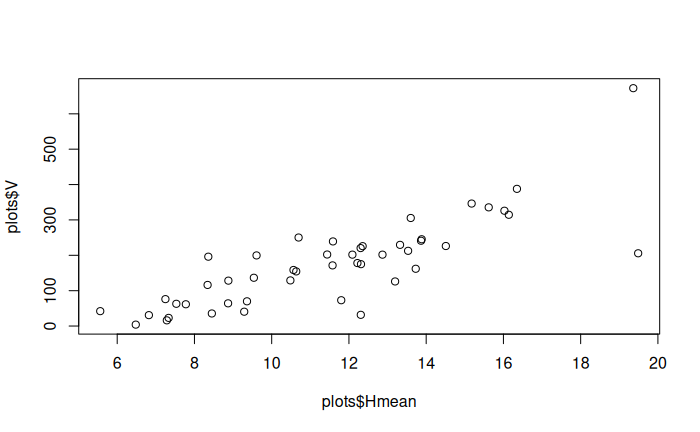

```r
plot(plots$Hmean,plots$V)
```

## Side note on modeling

A more proper modeling approach. log-log models are often used in the area-based approach to linearize the relationships. However, when back transforming *exp(pred)* a bias is introduce. Thus, with computers nowadays nonlinear models can be used while still doing variable selection in the log-log space

```r
library(leaps)
library(ggplot2)
dat <- subset(plots, select=c(V,Hmax:Hcv,H10:D9))
dat <- st_drop_geometry(dat)
head(dat)
```

|  | V | Hmax | Hmean | Hsd | Hcv | H10 | H20 | H30 | H40 | H50 | H60 | H70 | H80 | H90 | H95 | D0 | D1 | D2 | D3 | D4 | D5 | D6 | D7 | D8 | D9 |
| --- | --- | --- | --- | --- | --- | --- | --- | --- | --- | --- | --- | --- | --- | --- | --- | --- | --- | --- | --- | --- | --- | --- | --- | --- | --- |
| 1 | 171.48019 | 22.34 | 11.575928 | 3.873993 | 0.3346594 | 6.120 | 8.004 | 9.781 | 11.288 | 12.21 | 12.952 | 13.860 | 14.646 | 15.873 | 17.2300 | 0.6223840 | 0.6023658 | 0.5809827 | 0.5454959 | 0.4940855 | 0.4399454 | 0.37989081 | 0.26706096 | 0.15605096 | 0.06960874 |
| 2 | 161.93926 | 22.02 | 13.729396 | 5.001242 | 0.3642725 | 4.554 | 9.414 | 12.608 | 14.118 | 15.37 | 16.406 | 16.994 | 17.602 | 18.808 | 19.2180 | 0.4995563 | 0.4631766 | 0.4427684 | 0.4250222 | 0.4046140 | 0.3833185 | 0.35847382 | 0.30346051 | 0.23158829 | 0.10559006 |
| 3 | 225.83901 | 23.03 | 12.354471 | 5.200843 | 0.4209685 | 5.074 | 7.178 | 8.572 | 10.538 | 13.24 | 14.620 | 15.890 | 17.214 | 18.790 | 20.1490 | 0.6852527 | 0.6524231 | 0.5961438 | 0.5325690 | 0.4544033 | 0.3981240 | 0.35435122 | 0.26836894 | 0.17717561 | 0.08650339 |
| 4 | 212.65039 | 21.13 | 13.532236 | 4.209595 | 0.3110791 | 7.312 | 10.102 | 11.592 | 13.040 | 14.10 | 15.342 | 16.084 | 17.190 | 18.580 | 19.4240 | 0.6914324 | 0.6773762 | 0.6539491 | 0.6244980 | 0.5856760 | 0.5361446 | 0.45113788 | 0.34002677 | 0.22556894 | 0.11244980 |
| 5 | 16.12858 | 19.97 | 7.284962 | 4.085395 | 0.5607983 | 3.145 | 3.920 | 4.790 | 5.600 | 6.38 | 7.260 | 8.260 | 9.520 | 13.300 | 17.3475 | 0.6905996 | 0.5862324 | 0.4581791 | 0.3260548 | 0.2168764 | 0.1321244 | 0.08697261 | 0.07253886 | 0.06328645 | 0.05551443 |
| 6 | 158.50063 | 19.36 | 10.564682 | 3.958364 | 0.3746789 | 4.480 | 6.544 | 8.481 | 10.040 | 11.44 | 12.340 | 13.260 | 14.186 | 14.863 | 15.6665 | 0.6494668 | 0.6164431 | 0.5761954 | 0.5331957 | 0.4895081 | 0.4389405 | 0.38390093 | 0.31922945 | 0.21878225 | 0.11936705 |

```r
Xy <- log(dat)
mod <- lm(V~.,data=Xy)
summary(mod)
```

```
Call:
lm(formula = V ~ ., data = Xy)

Residuals:
    Min      1Q  Median      3Q     Max
-0.5603 -0.1980 -0.0375  0.1677  0.8497

Coefficients: (1 not defined because of singularities)
             Estimate Std. Error t value Pr(>|t|)
(Intercept)   4.81369    7.97434   0.604 0.551986
Hmax          2.64078    2.46386   1.072 0.294925
Hmean        -5.00277   26.62537  -0.188 0.852607
Hsd           0.78124    3.04846   0.256 0.800019
Hcv                NA         NA      NA       NA
H10          -1.09355    1.67451  -0.653 0.520195
H20          -1.70394    3.67301  -0.464 0.647074
H30           3.67745    5.83122   0.631 0.534487
H40          -7.34138    6.84893  -1.072 0.294883
H50          -7.37435    8.23015  -0.896 0.379526
H60           5.78916   10.59892   0.546 0.590186
H70          -4.64592    9.63233  -0.482 0.634133
H80           3.20581    8.80851   0.364 0.719223
H90         -26.53654    8.28218  -3.204 0.003940 **
H95          38.23290   15.16975   2.520 0.019116 *
D0          -20.12175    9.10862  -2.209 0.037402 *
D1          -12.27450    7.63298  -1.608 0.121458
D2           33.32199    7.55732   4.409 0.000203 ***
D3          -11.40030    5.81674  -1.960 0.062232 .
D4            0.06292    7.97506   0.008 0.993773
D5            4.82543    7.01410   0.688 0.498357
D6            3.32840    4.48461   0.742 0.465489
D7           -0.99472    2.62227  -0.379 0.707920
D8            3.08609    1.16586   2.647 0.014404 *
D9            0.97014    0.85357   1.137 0.267425
---
Signif. codes:  0 ‘***’ 0.001 ‘**’ 0.01 ‘*’ 0.05 ‘.’ 0.1 ‘ ’ 1

Residual standard error: 0.46 on 23 degrees of freedom
Multiple R-squared:  0.8869,    Adjusted R-squared:  0.7738
F-statistic: 7.842 on 23 and 23 DF,  p-value: 2.848e-06
```

```r
# Step wise model selection
stepmod <- step(mod,trace=0)
summary(stepmod) # To many variables
```

```
Call:
lm(formula = V ~ Hmax + H10 + H40 + H90 + H95 + D0 + D1 + D2 +
    D3 + D5 + D8 + D9, data = Xy)

Residuals:
     Min       1Q   Median       3Q      Max
-0.64546 -0.22482 -0.03334  0.22632  1.02122

Coefficients:
            Estimate Std. Error t value Pr(>|t|)
(Intercept)   3.5081     1.9948   1.759 0.087631 .
Hmax          2.2242     1.3748   1.618 0.114924
H10          -1.8702     0.6293  -2.972 0.005406 **
H40          -9.0155     2.2701  -3.971 0.000351 ***
H90         -24.1986     4.9231  -4.915 2.21e-05 ***
H95          33.6015     6.9016   4.869 2.54e-05 ***
D0          -17.5082     5.0005  -3.501 0.001316 **
D1          -12.3914     6.1976  -1.999 0.053610 .
D2           32.5512     5.7288   5.682 2.23e-06 ***
D3          -12.2517     3.4877  -3.513 0.001275 **
D5            7.0467     1.5545   4.533 6.87e-05 ***
D8            2.4946     0.6321   3.946 0.000378 ***
D9            0.9621     0.6328   1.520 0.137663
---
Signif. codes:  0 ‘***’ 0.001 ‘**’ 0.01 ‘*’ 0.05 ‘.’ 0.1 ‘ ’ 1

Residual standard error: 0.4018 on 34 degrees of freedom
Multiple R-squared:  0.8724,    Adjusted R-squared:  0.8274
F-statistic: 19.37 on 12 and 34 DF,  p-value: 8.741e-12
```

```r
# Best subset nmax Indicate largest model
reg <- regsubsets(V~.,data=Xy,nvmax=3,really.big=TRUE)
```

```
Reordering variables and trying again:
```

```r
summary(reg)
```

[output not shown]

```r
mod <- lm(V~H70+D2,data=Xy)
summary(mod)
```

```
Call:
lm(formula = V ~ H70 + D2, data = Xy)

Residuals:
     Min       1Q   Median       3Q      Max
-2.05596 -0.15269 -0.01243  0.20860  0.92736

Coefficients:
            Estimate Std. Error t value Pr(>|t|)
(Intercept)  0.01601    0.89838   0.018  0.98586
H70          2.12779    0.30487   6.979 1.23e-08 ***
D2           1.07478    0.32809   3.276  0.00206 **
---
Signif. codes:  0 ‘***’ 0.001 ‘**’ 0.01 ‘*’ 0.05 ‘.’ 0.1 ‘ ’ 1

Residual standard error: 0.5492 on 44 degrees of freedom
Multiple R-squared:  0.6916,    Adjusted R-squared:  0.6776
F-statistic: 49.33 on 2 and 44 DF,  p-value: 5.763e-12
```

```r
# Fitting the nonlinear version of the log-log model
mod <- nls(V~b0*H70^b1*D2^b2,data=dat,start=c(b0=1,b1=1,b2=1))
summary(mod)
```

```
Formula: V ~ b0 * H70^b1 * D2^b2

Parameters:
   Estimate Std. Error t value Pr(>|t|)
b0   2.4222     1.2702   1.907   0.0631 .
b1   1.8111     0.1703  10.633 9.74e-14 ***
b2   0.9898     0.1630   6.073 2.63e-07 ***
---
Signif. codes:  0 ‘***’ 0.001 ‘**’ 0.01 ‘*’ 0.05 ‘.’ 0.1 ‘ ’ 1

Residual standard error: 44.45 on 44 degrees of freedom

Number of iterations to convergence: 8
Achieved convergence tolerance: 3.144e-07
```

## Wall to wall prediction

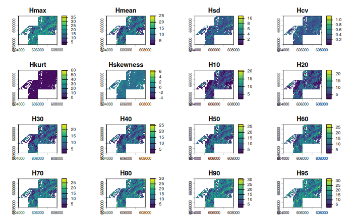

```r
library(terra)
# opt_output_files(ctgdz) <- "data/vaaler/metrics/{ORIGINALFILENAME}_metrics" #Output directory NB files exist in downloaded data.
# metrics_w2w <- pixel_metrics(ctgdz, ~stdmetricsNOR(Z), res = sqrt(250), pkg = "terra")

rasters <- lapply(list.files("data/vaaler/metrics", full.names = T, pattern = ".tif$"), rast)
metrics_w2w <- do.call(mosaic, rasters)
plot(metrics_w2w)
```

```r
#list.files()
```

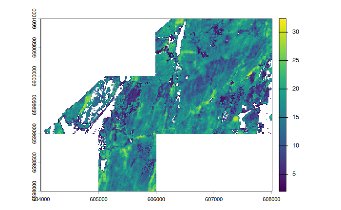

```r
#Do predictions
library(terra)
plot(metrics_w2w$H95)
```

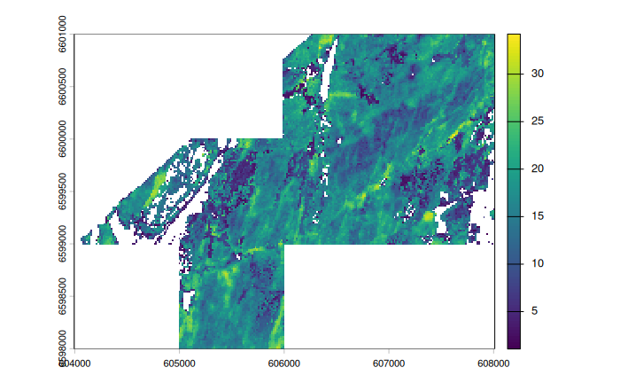

```r
TH_pred <- predict(metrics_w2w, modTH) # Predicting top height
plot(TH_pred)
```

```r
#Export predictions
#writeRaster(TH_pred,"data/TH.tif")
```

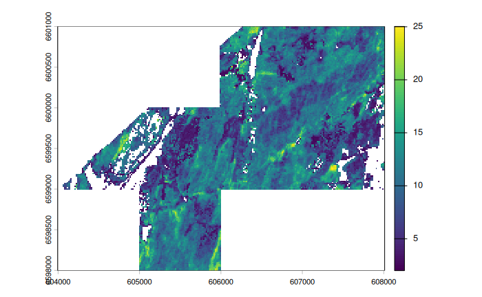

```r
plot(metrics_w2w$Hmean)
```

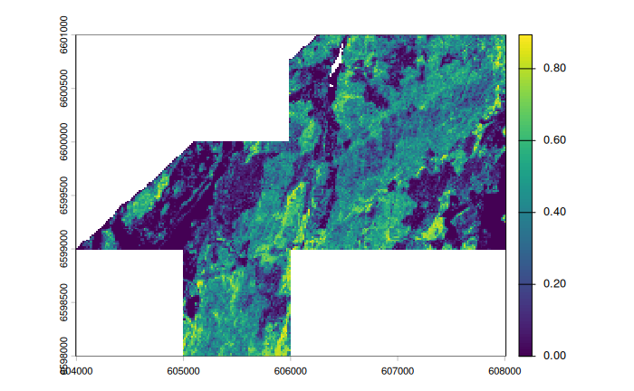

```r
plot(metrics_w2w$D5)
```

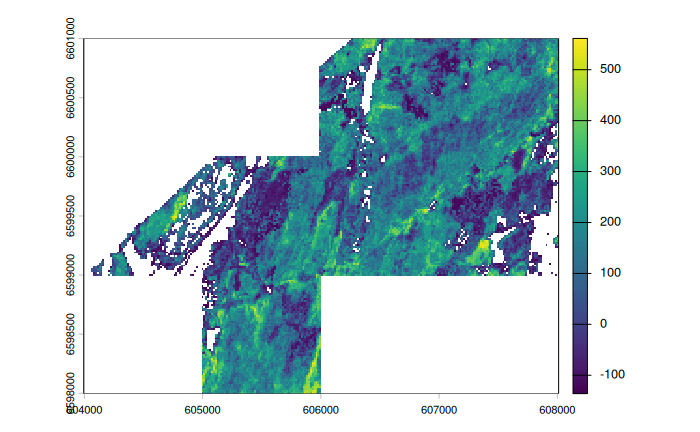

```r
V_pred <- predict(metrics_w2w, modV) # Predicting volume
plot(V_pred,zlim=c(0,500))
```

```r
#writeRaster(V_pred,"data/V.tif")
```

# References

Næsset. 2014. “Area-Based Inventory in Norway–From Innovation to an Operational Reality.” In *Forestry Applications of Airborne Laser Scanning - Concepts and Case Studies*, edited by Matti Maltamo, Erik Næsset, and Jari Vauhkonen. Springer.

Næsset, and T Gobakken. 2008. “Estimation of Above- and Below-Ground Biomass Across Regions of the Boreal Forest Zone Using Airborne Laser.” *Remote Sens. Environ.* 112: 3079–90.